# Assignment 4 Boosting

Derek Shat

11/17/2021

```r
library(tidyverse)
library(tidymodels)
library(knitr)
library(doParallel)
library(knitr)
library(scales)
library(baguette)
library(tictoc)
library(ISLR)
data(Smarket)
```

# First models

```r
market_dt <- Smarket %>%
  as_tibble() %>%
  select(-Today)

market_dt %>% summarize(total_values = sum(!is.na(.)),
                        missing = sum(is.na(.)))
```

```
## # A tibble: 1 x 2
##   total_values missing
##          <int>   <int>
## 1        10000       0
```

```r
# no need to impute for later
perf_meas <- metric_set(roc_auc, accuracy,kap,mn_log_loss)

set.seed(123)
market_split <- initial_split(market_dt, prop = 0.7, strata = Direction)
market_train <- training(market_split)
market_test <- testing(market_split)
set.seed(456)
market_folds <- market_train %>%
  vfold_cv(v = 5, repeats = 5, strata = Direction)

base_boost_rec <-
  recipe(Direction ~., data = market_train) %>%
  update_role(Year, new_role = 'ID') %>%
  step_zv(all_numeric_predictors())

enhanced_boost_rec <- base_boost_rec %>%
  step_normalize(all_numeric_predictors()) %>%
  step_bs(all_numeric_predictors())

boost_mod <-
  boost_tree(trees = tune(),
             learn_rate = tune()) %>%
  set_mode('classification') %>%
  set_engine('xgboost')

boost_grid <- grid_latin_hypercube(trees(range = c(1,500)),
                       learn_rate(range = c(-2,-0.5)),
                       size = 20)

base_boost_wf <-
  workflow() %>%
  add_recipe(base_boost_rec) %>%
  add_model(boost_mod)

enhanced_boost_wf <-
  workflow() %>%
  add_recipe(enhanced_boost_rec) %>%
  add_model(boost_mod)
```

## Tuning

```r
all_cores <- parallel::detectCores(logical = FALSE)
cl <- makePSOCKcluster(all_cores)
registerDoParallel(cl)

tune_ctrl <- control_resamples(save_pred = TRUE)

tic()
base_boost_res <-
  base_boost_wf %>%
    tune_grid(market_folds,
              grid = boost_grid,
              metrics = perf_meas,
              control = tune_ctrl)
toc()
```

```
## 140.37 sec elapsed
```

```r
tic()
enhanced_boost_res <-
  enhanced_boost_wf %>%
    tune_grid(market_folds,
              grid = boost_grid,
              metrics = perf_meas,
              control = tune_ctrl)
toc()
```

```
## 191.75 sec elapsed
```

```r
stopCluster(cl)
```

## Results

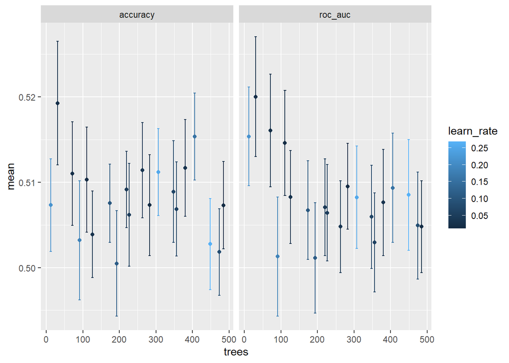

```r
base_boost_res %>%
  collect_metrics() %>%
  filter(.metric == c('accuracy','roc_auc')) %>%
  ggplot(aes(x = trees, y = mean, col = learn_rate))+
    geom_point() +
    geom_errorbar(aes(ymin = mean - std_err, ymax = mean + std_err)) +
  facet_grid(~.metric, scales = 'free')
```

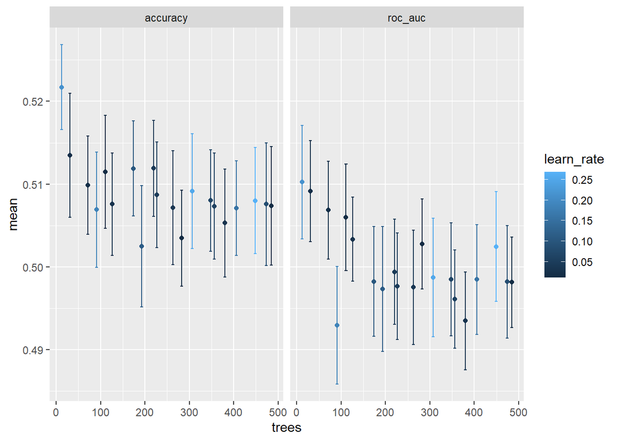

```r
enhanced_boost_res %>%
  collect_metrics() %>%
  filter(.metric == c('accuracy','roc_auc')) %>%
  ggplot(aes(x = trees, y = mean, col = learn_rate))+
    geom_point() +
    geom_errorbar(aes(ymin = mean - std_err, ymax = mean + std_err)) +
  facet_grid(~.metric, scales = 'free')
```

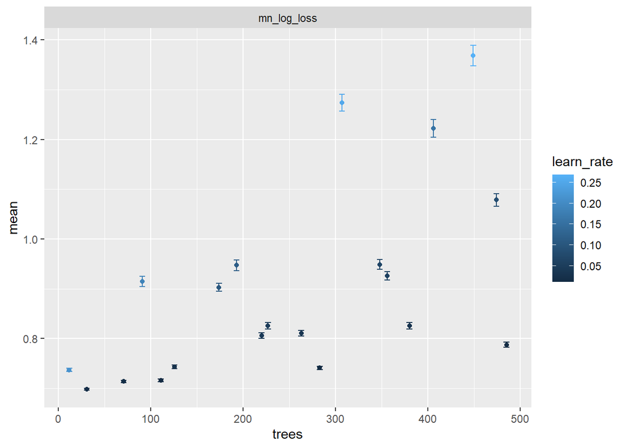

```r
base_boost_res %>%
  collect_metrics() %>%
  filter(.metric == 'mn_log_loss') %>%
  ggplot(aes(x = trees, y = mean, col = learn_rate))+
    geom_point() +
    geom_errorbar(aes(ymin = mean - std_err, ymax = mean + std_err)) +
  facet_grid(~.metric, scales = 'free')
```

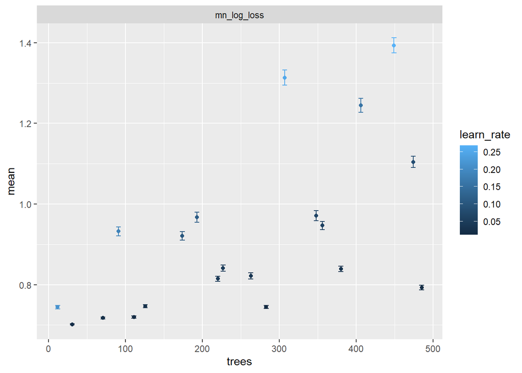

```r
enhanced_boost_res %>%
  collect_metrics() %>%
  filter(.metric == 'mn_log_loss') %>%
  ggplot(aes(x = trees, y = mean, col = learn_rate))+
    geom_point() +
    geom_errorbar(aes(ymin = mean - std_err, ymax = mean + std_err)) +
  facet_grid(~.metric, scales = 'free')
```

```r
show_best(base_boost_res,metric = 'kap') %>% kable(digits=3)
```

| trees | learn_rate | .metric | .estimator | mean | n | std_err | .config |
| --- | --- | --- | --- | --- | --- | --- | --- |
| 31 | 0.019 | kap | binary | 0.031 | 25 | 0.014 | Preprocessor1_Model04 |
| 406 | 0.157 | kap | binary | 0.029 | 25 | 0.010 | Preprocessor1_Model16 |
| 307 | 0.253 | kap | binary | 0.021 | 25 | 0.010 | Preprocessor1_Model19 |
| 380 | 0.029 | kap | binary | 0.021 | 25 | 0.011 | Preprocessor1_Model07 |
| 263 | 0.036 | kap | binary | 0.020 | 25 | 0.011 | Preprocessor1_Model08 |

```r
show_best(enhanced_boost_res,metric = 'kap') %>% kable(digits=3)
```

| trees | learn_rate | .metric | .estimator | mean | n | std_err | .config |
| --- | --- | --- | --- | --- | --- | --- | --- |
| 12 | 0.214 | kap | binary | 0.039 | 25 | 0.010 | Preprocessor1_Model18 |
| 31 | 0.019 | kap | binary | 0.021 | 25 | 0.015 | Preprocessor1_Model04 |
| 174 | 0.103 | kap | binary | 0.021 | 25 | 0.011 | Preprocessor1_Model14 |
| 220 | 0.041 | kap | binary | 0.020 | 25 | 0.012 | Preprocessor1_Model09 |
| 111 | 0.014 | kap | binary | 0.018 | 25 | 0.014 | Preprocessor1_Model02 |

```r
show_best(base_boost_res,metric = 'mn_log_loss') %>% kable(digits=3)
```

| trees | learn_rate | .metric | .estimator | mean | n | std_err | .config |
| --- | --- | --- | --- | --- | --- | --- | --- |
| 31 | 0.019 | mn_log_loss | binary | 0.698 | 25 | 0.002 | Preprocessor1_Model04 |
| 71 | 0.020 | mn_log_loss | binary | 0.714 | 25 | 0.003 | Preprocessor1_Model05 |
| 111 | 0.014 | mn_log_loss | binary | 0.716 | 25 | 0.003 | Preprocessor1_Model02 |
| 12 | 0.214 | mn_log_loss | binary | 0.737 | 25 | 0.003 | Preprocessor1_Model18 |
| 283 | 0.011 | mn_log_loss | binary | 0.741 | 25 | 0.003 | Preprocessor1_Model01 |

```r
show_best(enhanced_boost_res,metric = 'mn_log_loss') %>% kable(digits=3)
```

| trees | learn_rate | .metric | .estimator | mean | n | std_err | .config |
| --- | --- | --- | --- | --- | --- | --- | --- |
| 31 | 0.019 | mn_log_loss | binary | 0.701 | 25 | 0.001 | Preprocessor1_Model04 |
| 71 | 0.020 | mn_log_loss | binary | 0.718 | 25 | 0.003 | Preprocessor1_Model05 |
| 111 | 0.014 | mn_log_loss | binary | 0.720 | 25 | 0.003 | Preprocessor1_Model02 |
| 12 | 0.214 | mn_log_loss | binary | 0.744 | 25 | 0.005 | Preprocessor1_Model18 |
| 283 | 0.011 | mn_log_loss | binary | 0.745 | 25 | 0.004 | Preprocessor1_Model01 |

```r
show_best(base_boost_res,metric = 'accuracy') %>% kable(digits=3)
```

| trees | learn_rate | .metric | .estimator | mean | n | std_err | .config |
| --- | --- | --- | --- | --- | --- | --- | --- |
| 31 | 0.019 | accuracy | binary | 0.519 | 25 | 0.007 | Preprocessor1_Model04 |
| 406 | 0.157 | accuracy | binary | 0.515 | 25 | 0.005 | Preprocessor1_Model16 |
| 380 | 0.029 | accuracy | binary | 0.512 | 25 | 0.006 | Preprocessor1_Model07 |
| 263 | 0.036 | accuracy | binary | 0.511 | 25 | 0.006 | Preprocessor1_Model08 |
| 307 | 0.253 | accuracy | binary | 0.511 | 25 | 0.005 | Preprocessor1_Model19 |

```r
show_best(enhanced_boost_res,metric = 'accuracy') %>% kable(digits=3)
```

| trees | learn_rate | .metric | .estimator | mean | n | std_err | .config |
| --- | --- | --- | --- | --- | --- | --- | --- |
| 12 | 0.214 | accuracy | binary | 0.522 | 25 | 0.005 | Preprocessor1_Model18 |
| 31 | 0.019 | accuracy | binary | 0.513 | 25 | 0.007 | Preprocessor1_Model04 |
| 220 | 0.041 | accuracy | binary | 0.512 | 25 | 0.006 | Preprocessor1_Model09 |
| 174 | 0.103 | accuracy | binary | 0.512 | 25 | 0.006 | Preprocessor1_Model14 |
| 111 | 0.014 | accuracy | binary | 0.511 | 25 | 0.007 | Preprocessor1_Model02 |

From these results, we can see that there does not seem to be much of a correlation between trees and mean. There also seems to be an inverse correlation between learn rate and mean. For the following experiments, trees have been tuned to a smaller range for faster processing, and learn rate will be tuned to smaller amounts. The next experiment shown will introduce tree_depth and stop_iter to the model in an attempt to get better results for the metrics, with a focus on maximizing kappa.

# Second models and tuning

```r
boost_mod2 <-
  boost_tree(trees = tune(),
             learn_rate = tune(),
             tree_depth = tune(),
             stop_iter = tune()) %>%
  set_mode('classification') %>%
  set_engine('xgboost')

boost_grid2 <-
    grid_latin_hypercube(trees(range = c(1,50)),
                       learn_rate(range = c(-5,-1.5)),
                       tree_depth(range=c(1,20)),
                       stop_iter(range = c(1,20)),
                       size = 30)

base_boost_wf2 <-
  workflow() %>%
  add_recipe(base_boost_rec) %>%
  add_model(boost_mod2)

enhanced_boost_wf2 <-
  workflow() %>%
  add_recipe(enhanced_boost_rec) %>%
  add_model(boost_mod2)


all_cores <- parallel::detectCores(logical = FALSE)
cl <- makePSOCKcluster(all_cores)
registerDoParallel(cl)

tune_ctrl <- control_resamples(save_pred = TRUE)

tic()
base_boost_res2 <-
  base_boost_wf2 %>%
    tune_grid(market_folds,
              grid = boost_grid2,
              metrics = perf_meas,
              control = tune_ctrl)
toc()
```

```
## 125.04 sec elapsed
```

```r
tic()
enhanced_boost_res2 <-
  enhanced_boost_wf2 %>%
    tune_grid(market_folds,
              grid = boost_grid2,
              metrics = perf_meas,
              control = tune_ctrl)
toc()
```

```
## 117.75 sec elapsed
```

```r
stopCluster(cl)
```

## Results

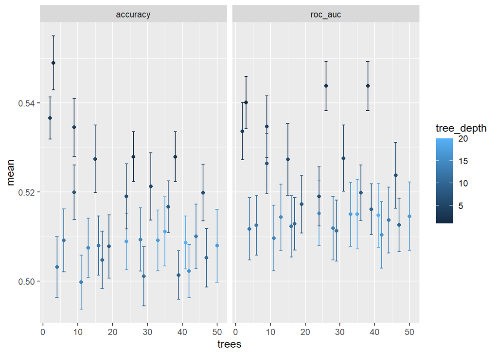

```r
base_boost_res2 %>%
  collect_metrics() %>%
  filter(.metric == c('accuracy','roc_auc')) %>%
  ggplot(aes(x = trees, y = mean, col = tree_depth))+
    geom_point() +
    geom_errorbar(aes(ymin = mean - std_err, ymax = mean + std_err)) +
  facet_grid(~.metric, scales = 'free')
```

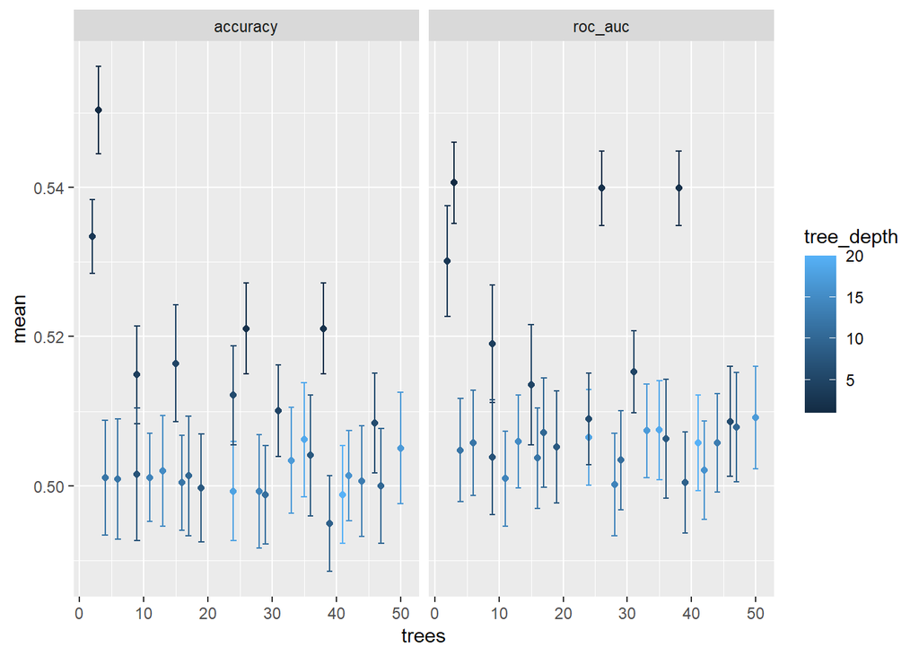

```r
enhanced_boost_res2 %>%
  collect_metrics() %>%
  filter(.metric == c('accuracy','roc_auc')) %>%
  ggplot(aes(x = trees, y = mean, col = tree_depth))+
    geom_point() +
    geom_errorbar(aes(ymin = mean - std_err, ymax = mean + std_err)) +
  facet_grid(~.metric, scales = 'free')
```

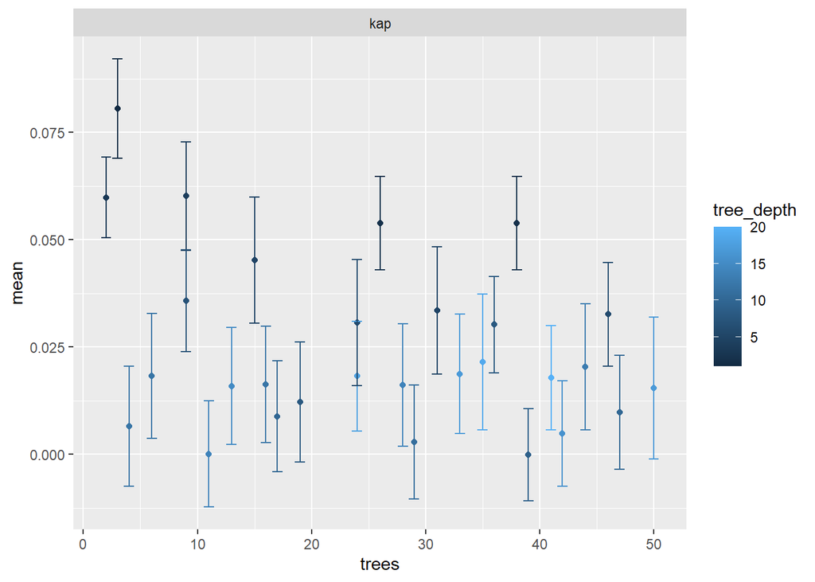

```r
base_boost_res2 %>%
  collect_metrics() %>%
  filter(.metric == 'kap') %>%
  ggplot(aes(x = trees, y = mean, col = tree_depth))+
    geom_point() +
    geom_errorbar(aes(ymin = mean - std_err, ymax = mean + std_err)) +
  facet_grid(~.metric, scales = 'free')
```

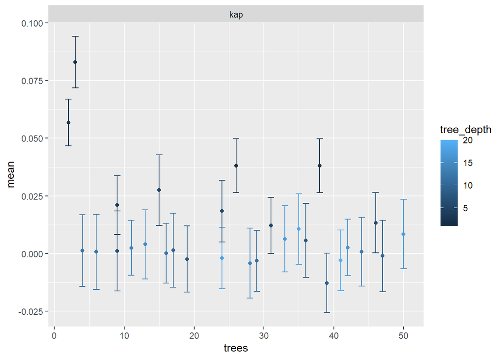

```r
enhanced_boost_res2 %>%
  collect_metrics() %>%
  filter(.metric == 'kap') %>%
  ggplot(aes(x = trees, y = mean, col = tree_depth))+
    geom_point() +
    geom_errorbar(aes(ymin = mean - std_err, ymax = mean + std_err)) +
  facet_grid(~.metric, scales = 'free')
```

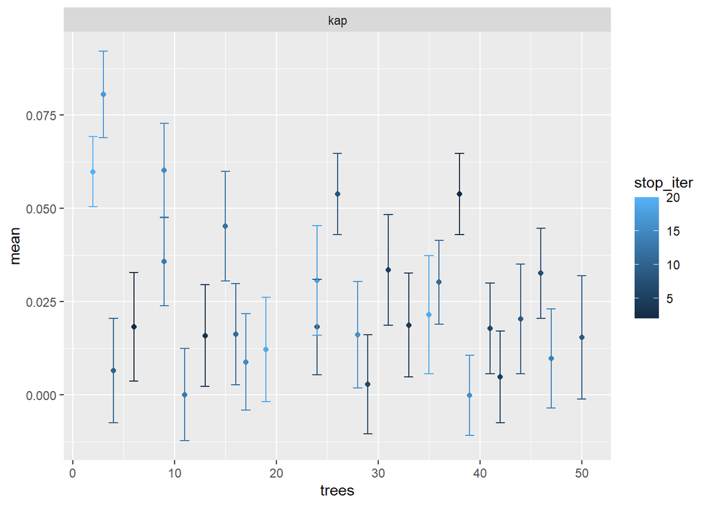

```r
base_boost_res2 %>%
  collect_metrics() %>%
  filter(.metric == 'kap') %>%
  ggplot(aes(x = trees, y = mean, col = stop_iter))+
    geom_point() +
    geom_errorbar(aes(ymin = mean - std_err, ymax = mean + std_err)) +
  facet_grid(~.metric, scales = 'free')
```

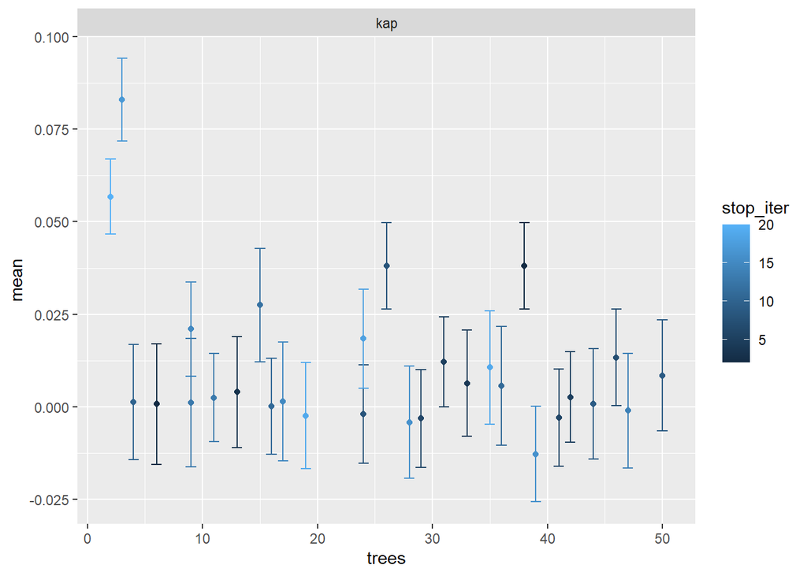

```r
enhanced_boost_res2 %>%
  collect_metrics() %>%
  filter(.metric == 'kap') %>%
  ggplot(aes(x = trees, y = mean, col = stop_iter))+
    geom_point() +
    geom_errorbar(aes(ymin = mean - std_err, ymax = mean + std_err)) +
  facet_grid(~.metric, scales = 'free')
```

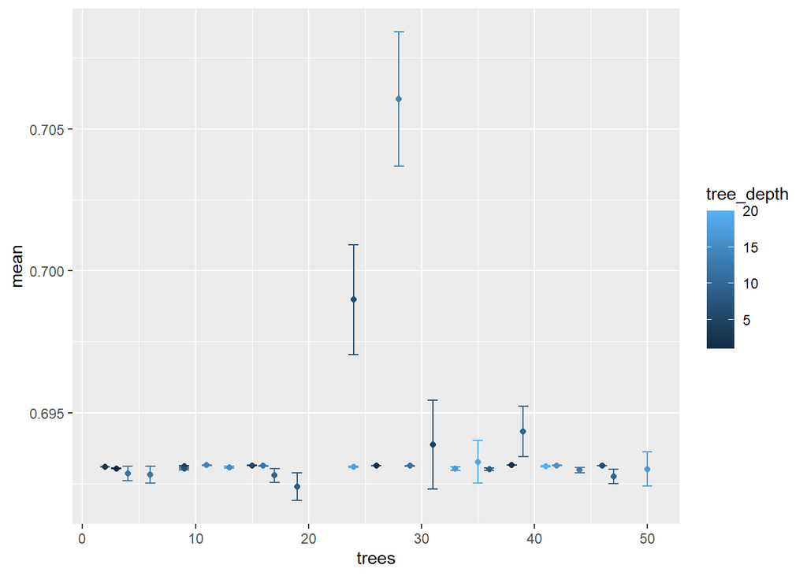

```r
base_boost_res2 %>%
  collect_metrics() %>%
  filter(.metric == 'mn_log_loss') %>%
  ggplot(aes(x = trees, y = mean, col = tree_depth))+
    geom_point() +
    geom_errorbar(aes(ymin = mean - std_err, ymax = mean + std_err))
```

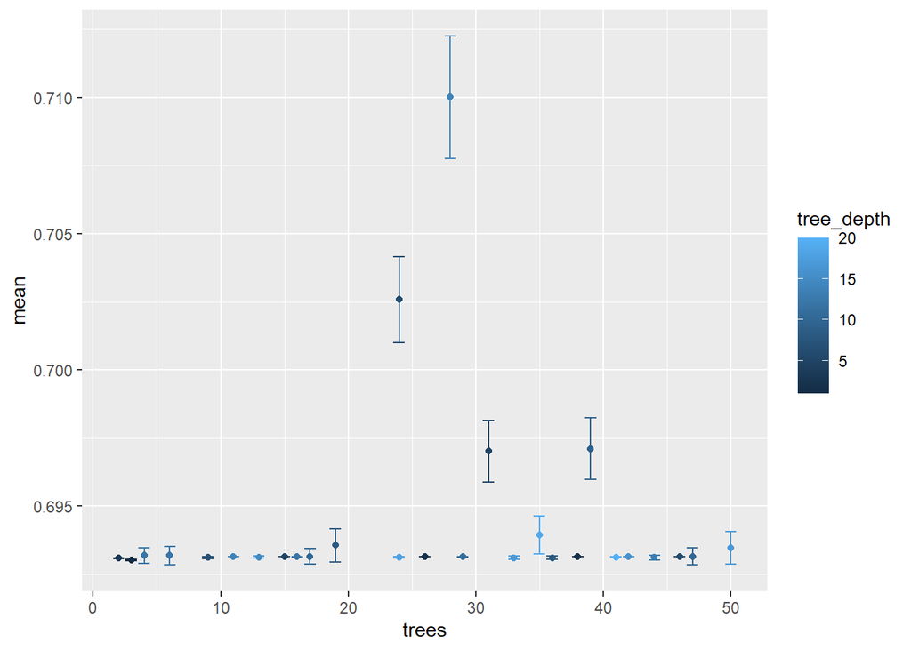

```r
enhanced_boost_res2 %>%
  collect_metrics() %>%
  filter(.metric == 'mn_log_loss') %>%
  ggplot(aes(x = trees, y = mean, col = tree_depth))+
    geom_point() +
    geom_errorbar(aes(ymin = mean - std_err, ymax = mean + std_err))
```

```r
show_best(base_boost_res2,metric = 'kap') %>% kable(digits=3)
```

| trees | tree_depth | learn_rate | stop_iter | .metric | .estimator | mean | n | std_err | .config |
| --- | --- | --- | --- | --- | --- | --- | --- | --- | --- |
| 3 | 1 | 0.003 | 17 | kap | binary | 0.081 | 25 | 0.012 | Preprocessor1_Model21 |
| 9 | 4 | 0.000 | 15 | kap | binary | 0.060 | 25 | 0.013 | Preprocessor1_Model10 |
| 2 | 3 | 0.002 | 20 | kap | binary | 0.060 | 25 | 0.009 | Preprocessor1_Model19 |
| 26 | 2 | 0.000 | 8 | kap | binary | 0.054 | 25 | 0.011 | Preprocessor1_Model04 |
| 38 | 2 | 0.000 | 2 | kap | binary | 0.054 | 25 | 0.011 | Preprocessor1_Model05 |

```r
show_best(enhanced_boost_res2,metric = 'kap') %>% kable(digits=3)
```

| trees | tree_depth | learn_rate | stop_iter | .metric | .estimator | mean | n | std_err | .config |
| --- | --- | --- | --- | --- | --- | --- | --- | --- | --- |
| 3 | 1 | 0.003 | 17 | kap | binary | 0.083 | 25 | 0.011 | Preprocessor1_Model21 |
| 2 | 3 | 0.002 | 20 | kap | binary | 0.057 | 25 | 0.010 | Preprocessor1_Model19 |
| 26 | 2 | 0.000 | 8 | kap | binary | 0.038 | 25 | 0.012 | Preprocessor1_Model04 |
| 38 | 2 | 0.000 | 2 | kap | binary | 0.038 | 25 | 0.012 | Preprocessor1_Model05 |
| 15 | 5 | 0.000 | 12 | kap | binary | 0.028 | 25 | 0.015 | Preprocessor1_Model02 |

```r
show_best(base_boost_res2,metric = 'mn_log_loss') %>% kable(digits=3)
```

| trees | tree_depth | learn_rate | stop_iter | .metric | .estimator | mean | n | std_err | .config |
| --- | --- | --- | --- | --- | --- | --- | --- | --- | --- |
| 19 | 8 | 0.006 | 19 | mn_log_loss | binary | 0.692 | 25 | 0 | Preprocessor1_Model24 |
| 47 | 10 | 0.001 | 14 | mn_log_loss | binary | 0.693 | 25 | 0 | Preprocessor1_Model18 |
| 17 | 10 | 0.003 | 15 | mn_log_loss | binary | 0.693 | 25 | 0 | Preprocessor1_Model22 |
| 6 | 12 | 0.009 | 2 | mn_log_loss | binary | 0.693 | 25 | 0 | Preprocessor1_Model26 |
| 4 | 12 | 0.011 | 10 | mn_log_loss | binary | 0.693 | 25 | 0 | Preprocessor1_Model27 |

```r
show_best(enhanced_boost_res2,metric = 'mn_log_loss') %>% kable(digits=3)
```

| trees | tree_depth | learn_rate | stop_iter | .metric | .estimator | mean | n | std_err | .config |
| --- | --- | --- | --- | --- | --- | --- | --- | --- | --- |
| 3 | 1 | 0.003 | 17 | mn_log_loss | binary | 0.693 | 25 | 0 | Preprocessor1_Model21 |
| 2 | 3 | 0.002 | 20 | mn_log_loss | binary | 0.693 | 25 | 0 | Preprocessor1_Model19 |
| 33 | 17 | 0.000 | 4 | mn_log_loss | binary | 0.693 | 25 | 0 | Preprocessor1_Model13 |
| 36 | 8 | 0.000 | 11 | mn_log_loss | binary | 0.693 | 25 | 0 | Preprocessor1_Model12 |
| 44 | 13 | 0.000 | 9 | mn_log_loss | binary | 0.693 | 25 | 0 | Preprocessor1_Model14 |

```r
show_best(base_boost_res2,metric = 'accuracy') %>% kable(digits=3)
```

| trees | tree_depth | learn_rate | stop_iter | .metric | .estimator | mean | n | std_err | .config |
| --- | --- | --- | --- | --- | --- | --- | --- | --- | --- |
| 3 | 1 | 0.003 | 17 | accuracy | binary | 0.549 | 25 | 0.006 | Preprocessor1_Model21 |
| 2 | 3 | 0.002 | 20 | accuracy | binary | 0.537 | 25 | 0.005 | Preprocessor1_Model19 |
| 9 | 4 | 0.000 | 15 | accuracy | binary | 0.535 | 25 | 0.007 | Preprocessor1_Model10 |
| 26 | 2 | 0.000 | 8 | accuracy | binary | 0.528 | 25 | 0.006 | Preprocessor1_Model04 |
| 38 | 2 | 0.000 | 2 | accuracy | binary | 0.528 | 25 | 0.006 | Preprocessor1_Model05 |

```r
show_best(enhanced_boost_res2,metric = 'accuracy') %>% kable(digits=3)
```

| trees | tree_depth | learn_rate | stop_iter | .metric | .estimator | mean | n | std_err | .config |
| --- | --- | --- | --- | --- | --- | --- | --- | --- | --- |
| 3 | 1 | 0.003 | 17 | accuracy | binary | 0.550 | 25 | 0.006 | Preprocessor1_Model21 |
| 2 | 3 | 0.002 | 20 | accuracy | binary | 0.533 | 25 | 0.005 | Preprocessor1_Model19 |
| 26 | 2 | 0.000 | 8 | accuracy | binary | 0.521 | 25 | 0.006 | Preprocessor1_Model04 |
| 38 | 2 | 0.000 | 2 | accuracy | binary | 0.521 | 25 | 0.006 | Preprocessor1_Model05 |
| 15 | 5 | 0.000 | 12 | accuracy | binary | 0.516 | 25 | 0.008 | Preprocessor1_Model02 |

```r
show_best(base_boost_res2,metric = 'roc_auc') %>% kable(digits=3)
```

| trees | tree_depth | learn_rate | stop_iter | .metric | .estimator | mean | n | std_err | .config |
| --- | --- | --- | --- | --- | --- | --- | --- | --- | --- |
| 26 | 2 | 0.000 | 8 | roc_auc | binary | 0.544 | 25 | 0.006 | Preprocessor1_Model04 |
| 38 | 2 | 0.000 | 2 | roc_auc | binary | 0.544 | 25 | 0.006 | Preprocessor1_Model05 |
| 3 | 1 | 0.003 | 17 | roc_auc | binary | 0.540 | 25 | 0.006 | Preprocessor1_Model21 |
| 9 | 4 | 0.000 | 15 | roc_auc | binary | 0.535 | 25 | 0.007 | Preprocessor1_Model10 |
| 2 | 3 | 0.002 | 20 | roc_auc | binary | 0.534 | 25 | 0.006 | Preprocessor1_Model19 |

```r
show_best(enhanced_boost_res2,metric = 'roc_auc') %>% kable(digits=3)
```

| trees | tree_depth | learn_rate | stop_iter | .metric | .estimator | mean | n | std_err | .config |
| --- | --- | --- | --- | --- | --- | --- | --- | --- | --- |
| 3 | 1 | 0.003 | 17 | roc_auc | binary | 0.541 | 25 | 0.005 | Preprocessor1_Model21 |
| 26 | 2 | 0.000 | 8 | roc_auc | binary | 0.540 | 25 | 0.005 | Preprocessor1_Model04 |
| 38 | 2 | 0.000 | 2 | roc_auc | binary | 0.540 | 25 | 0.005 | Preprocessor1_Model05 |
| 2 | 3 | 0.002 | 20 | roc_auc | binary | 0.530 | 25 | 0.007 | Preprocessor1_Model19 |
| 9 | 4 | 0.000 | 15 | roc_auc | binary | 0.519 | 25 | 0.008 | Preprocessor1_Model10 |

After several experiments, it is determined that a tree depth of 1 is most consistent at achieving the best results. Next are the final results of experiments, including mtry and min_n in the model.

# Third models and tuning

```r
boost_mod3 <-
  boost_tree(trees = tune(),
             learn_rate = tune(),
             tree_depth = 1,
             mtry = tune(),
             min_n = tune(),
             stop_iter = tune()) %>%
  set_mode('classification') %>%
  set_engine('xgboost')

boost_grid3 <-
  grid_latin_hypercube(trees(range = c(20,40)),
                       learn_rate(range = c(-6,-1.5)),
                       finalize(mtry(),market_train),
                       min_n(range = c(1,35)),
                       stop_iter(range = c(10,35)),
                       size = 100)

base_boost_wf3 <-
  workflow() %>%
  add_recipe(base_boost_rec) %>%
  add_model(boost_mod3)

enhanced_boost_wf3 <-
  workflow() %>%
  add_recipe(enhanced_boost_rec) %>%
  add_model(boost_mod3)

all_cores <- parallel::detectCores(logical = FALSE)
cl <- makePSOCKcluster(all_cores)
registerDoParallel(cl)

tune_ctrl <- control_resamples(save_pred = TRUE)

tic()
base_boost_res3 <-
  base_boost_wf3 %>%
    tune_grid(market_folds,
              grid = boost_grid3,
              metrics = perf_meas,
              control = tune_ctrl)
toc()
```

```
## 334.61 sec elapsed
```

```r
tic()
enhanced_boost_res3 <-
  enhanced_boost_wf3 %>%
    tune_grid(market_folds,
              grid = boost_grid3,
              metrics = perf_meas,
              control = tune_ctrl)
toc()
```

```
## 332.88 sec elapsed
```

```r
stopCluster(cl)
```

## Results

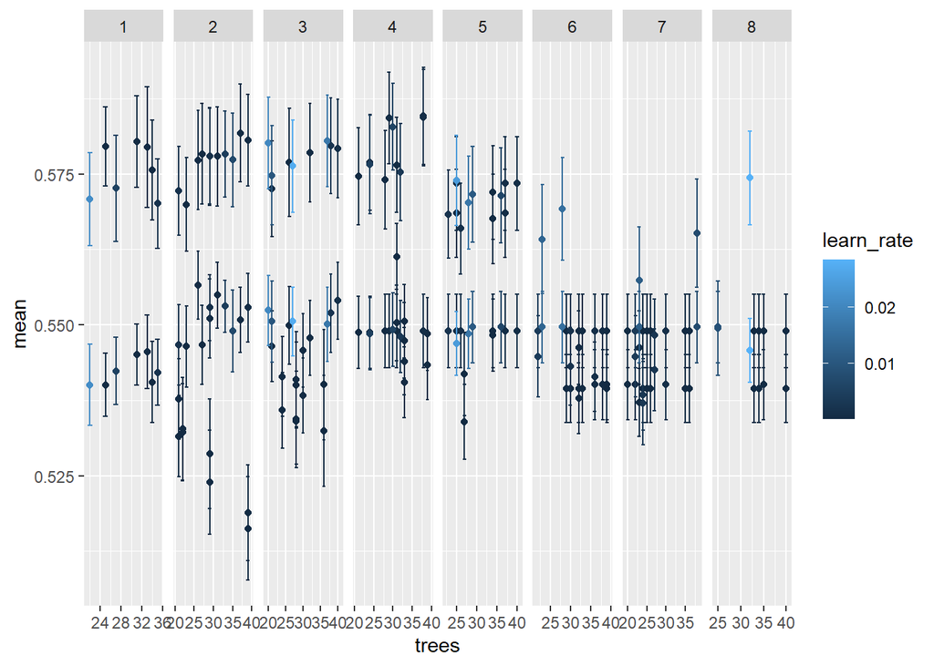

```r
base_boost_res3 %>%
  collect_metrics() %>%
  filter(.metric == c('accuracy','roc_auc')) %>%
  ggplot(aes(x = trees, y = mean, col = learn_rate))+
    geom_point() +
    geom_errorbar(aes(ymin = mean - std_err, ymax = mean + std_err)) +
  facet_grid(~mtry, scales = 'free')
```

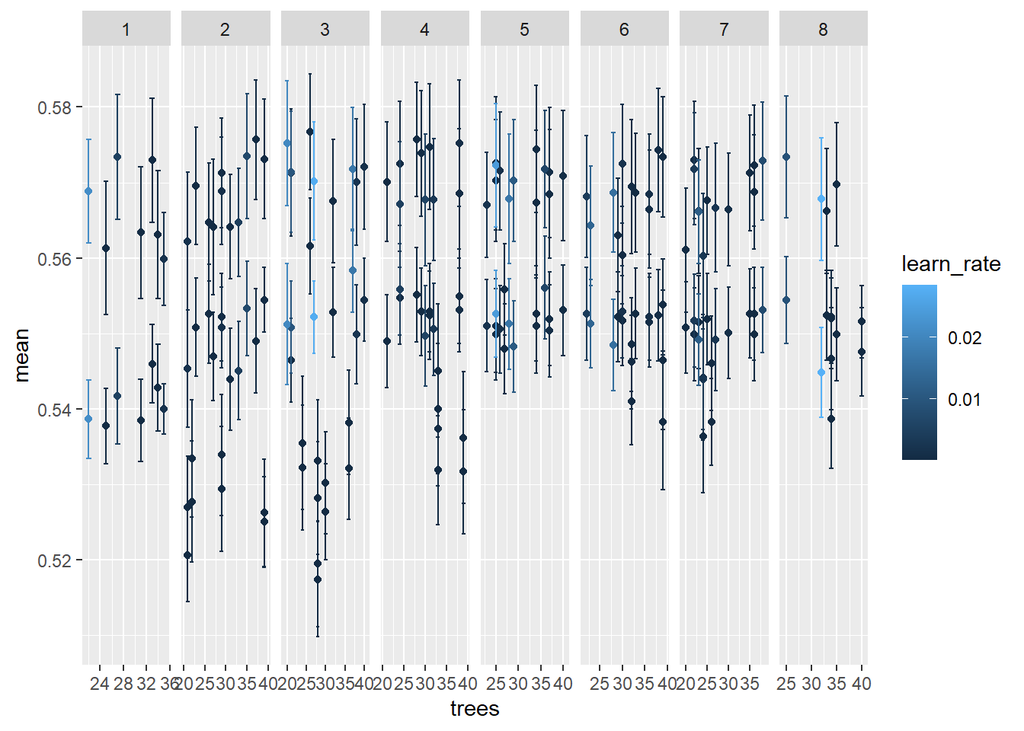

```r
enhanced_boost_res3 %>%
  collect_metrics() %>%
  filter(.metric == c('accuracy','roc_auc')) %>%
  ggplot(aes(x = trees, y = mean, col = learn_rate))+
    geom_point() +
    geom_errorbar(aes(ymin = mean - std_err, ymax = mean + std_err)) +
  facet_grid(~mtry, scales = 'free')
```

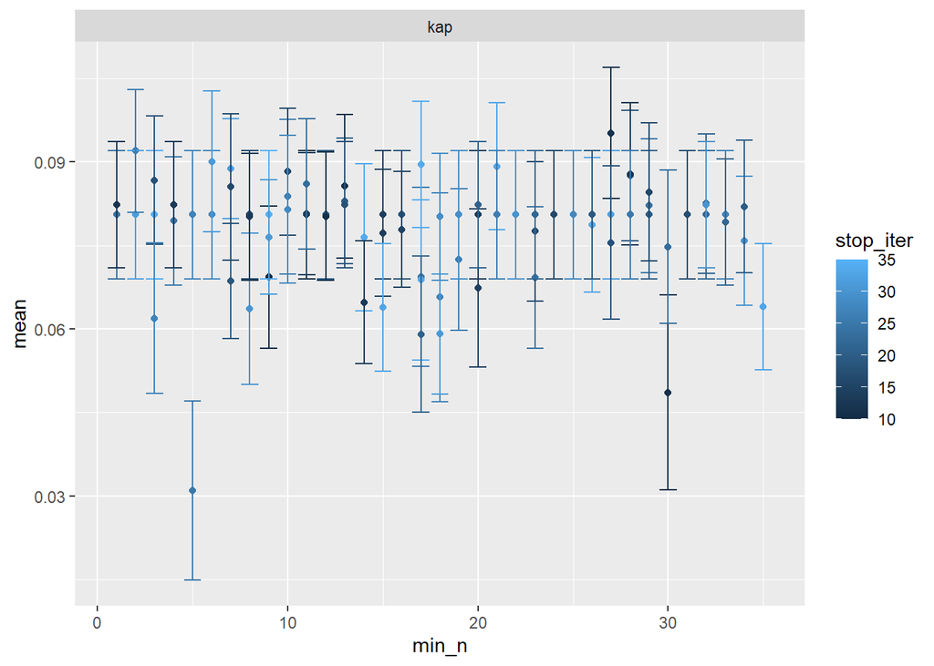

```r
base_boost_res3 %>%
  collect_metrics() %>%
  filter(.metric == 'kap') %>%
  ggplot(aes(x = min_n, y = mean, col = stop_iter))+
    geom_point() +
    geom_errorbar(aes(ymin = mean - std_err, ymax = mean + std_err)) +
  facet_grid(~.metric, scales = 'free')
```

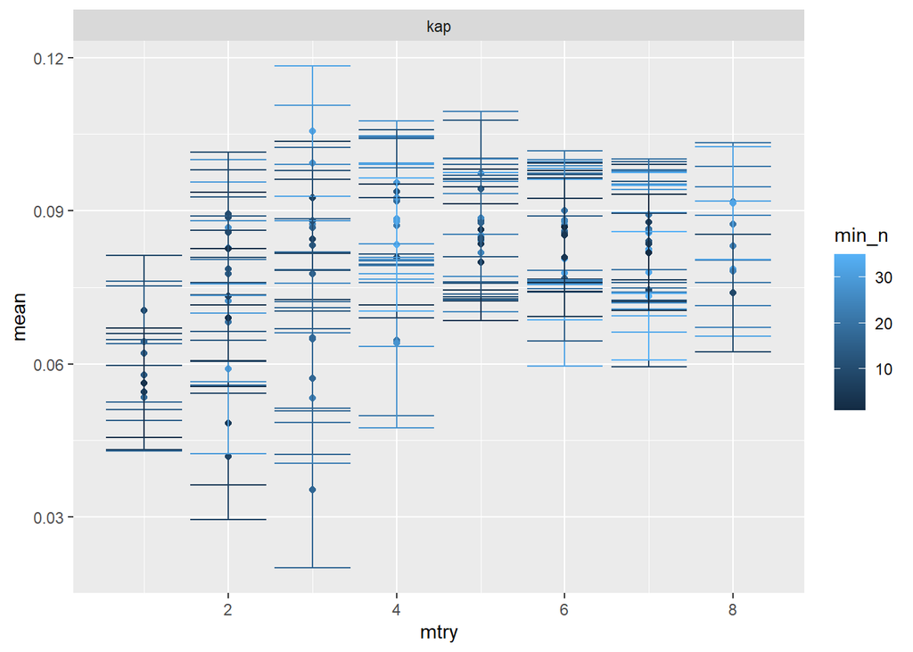

```r
enhanced_boost_res3 %>%
  collect_metrics() %>%
  filter(.metric == 'kap') %>%
  ggplot(aes(x = mtry, y = mean, col = min_n))+
    geom_point() +
    geom_errorbar(aes(ymin = mean - std_err, ymax = mean + std_err)) +
  facet_grid(~.metric, scales = 'free')
```

```r
show_best(base_boost_res3,metric = 'kap') %>% kable(digits=3)
```

| mtry | trees | min_n | learn_rate | stop_iter | .metric | .estimator | mean | n | std_err | .config |
| --- | --- | --- | --- | --- | --- | --- | --- | --- | --- | --- |
| 2 | 26 | 27 | 0.000 | 11 | kap | binary | 0.095 | 25 | 0.012 | Preprocessor1_Model056 |
| 2 | 31 | 2 | 0.000 | 26 | kap | binary | 0.092 | 25 | 0.011 | Preprocessor1_Model030 |
| 3 | 40 | 6 | 0.001 | 31 | kap | binary | 0.090 | 25 | 0.013 | Preprocessor1_Model068 |
| 3 | 20 | 17 | 0.020 | 34 | kap | binary | 0.090 | 25 | 0.011 | Preprocessor1_Model096 |
| 4 | 33 | 21 | 0.000 | 33 | kap | binary | 0.089 | 25 | 0.011 | Preprocessor1_Model007 |

```r
show_best(enhanced_boost_res3,metric = 'kap') %>% kable(digits=3)
```

| mtry | trees | min_n | learn_rate | stop_iter | .metric | .estimator | mean | n | std_err | .config |
| --- | --- | --- | --- | --- | --- | --- | --- | --- | --- | --- |
| 3 | 26 | 32 | 0.000 | 21 | kap | binary | 0.106 | 25 | 0.013 | Preprocessor1_Model024 |
| 3 | 37 | 29 | 0.017 | 16 | kap | binary | 0.099 | 25 | 0.011 | Preprocessor1_Model095 |
| 5 | 27 | 23 | 0.000 | 24 | kap | binary | 0.097 | 25 | 0.012 | Preprocessor1_Model006 |
| 4 | 31 | 28 | 0.000 | 12 | kap | binary | 0.095 | 25 | 0.012 | Preprocessor1_Model023 |
| 5 | 36 | 13 | 0.006 | 18 | kap | binary | 0.094 | 25 | 0.013 | Preprocessor1_Model085 |

```r
show_best(base_boost_res3,metric = 'mn_log_loss') %>% kable(digits=3)
```

| mtry | trees | min_n | learn_rate | stop_iter | .metric | .estimator | mean | n | std_err | .config |
| --- | --- | --- | --- | --- | --- | --- | --- | --- | --- | --- |
| 8 | 32 | 9 | 0.029 | 31 | mn_log_loss | binary | 0.687 | 25 | 0.001 | Preprocessor1_Model100 |
| 3 | 27 | 11 | 0.028 | 23 | mn_log_loss | binary | 0.688 | 25 | 0.001 | Preprocessor1_Model099 |
| 3 | 37 | 29 | 0.017 | 16 | mn_log_loss | binary | 0.688 | 25 | 0.001 | Preprocessor1_Model095 |
| 5 | 25 | 16 | 0.024 | 15 | mn_log_loss | binary | 0.688 | 25 | 0.001 | Preprocessor1_Model098 |
| 5 | 28 | 11 | 0.017 | 14 | mn_log_loss | binary | 0.689 | 25 | 0.001 | Preprocessor1_Model094 |

```r
show_best(enhanced_boost_res3,metric = 'mn_log_loss') %>% kable(digits=3)
```

| mtry | trees | min_n | learn_rate | stop_iter | .metric | .estimator | mean | n | std_err | .config |
| --- | --- | --- | --- | --- | --- | --- | --- | --- | --- | --- |
| 8 | 32 | 9 | 0.029 | 31 | mn_log_loss | binary | 0.687 | 25 | 0.001 | Preprocessor1_Model100 |
| 5 | 25 | 16 | 0.024 | 15 | mn_log_loss | binary | 0.688 | 25 | 0.001 | Preprocessor1_Model098 |
| 3 | 27 | 11 | 0.028 | 23 | mn_log_loss | binary | 0.688 | 25 | 0.001 | Preprocessor1_Model099 |
| 3 | 37 | 29 | 0.017 | 16 | mn_log_loss | binary | 0.688 | 25 | 0.001 | Preprocessor1_Model095 |
| 5 | 28 | 11 | 0.017 | 14 | mn_log_loss | binary | 0.689 | 25 | 0.000 | Preprocessor1_Model094 |

```r
show_best(base_boost_res3,metric = 'accuracy') %>% kable(digits=3)
```

| mtry | trees | min_n | learn_rate | stop_iter | .metric | .estimator | mean | n | std_err | .config |
| --- | --- | --- | --- | --- | --- | --- | --- | --- | --- | --- |
| 2 | 26 | 27 | 0.000 | 11 | accuracy | binary | 0.557 | 25 | 0.006 | Preprocessor1_Model056 |
| 2 | 31 | 2 | 0.000 | 26 | accuracy | binary | 0.555 | 25 | 0.005 | Preprocessor1_Model030 |
| 3 | 40 | 6 | 0.001 | 31 | accuracy | binary | 0.554 | 25 | 0.006 | Preprocessor1_Model068 |
| 2 | 33 | 7 | 0.004 | 32 | accuracy | binary | 0.553 | 25 | 0.004 | Preprocessor1_Model081 |
| 2 | 39 | 10 | 0.000 | 16 | accuracy | binary | 0.553 | 25 | 0.006 | Preprocessor1_Model057 |

```r
show_best(enhanced_boost_res3,metric = 'accuracy') %>% kable(digits=3)
```

| mtry | trees | min_n | learn_rate | stop_iter | .metric | .estimator | mean | n | std_err | .config |
| --- | --- | --- | --- | --- | --- | --- | --- | --- | --- | --- |
| 3 | 26 | 32 | 0.000 | 21 | accuracy | binary | 0.562 | 25 | 0.006 | Preprocessor1_Model024 |
| 3 | 37 | 29 | 0.017 | 16 | accuracy | binary | 0.558 | 25 | 0.005 | Preprocessor1_Model095 |
| 5 | 36 | 13 | 0.006 | 18 | accuracy | binary | 0.556 | 25 | 0.007 | Preprocessor1_Model085 |
| 5 | 27 | 23 | 0.000 | 24 | accuracy | binary | 0.556 | 25 | 0.006 | Preprocessor1_Model006 |
| 4 | 24 | 12 | 0.005 | 11 | accuracy | binary | 0.556 | 25 | 0.006 | Preprocessor1_Model082 |

```r
show_best(base_boost_res3,metric = 'roc_auc') %>% kable(digits=3)
```

| mtry | trees | min_n | learn_rate | stop_iter | .metric | .estimator | mean | n | std_err | .config |
| --- | --- | --- | --- | --- | --- | --- | --- | --- | --- | --- |
| 4 | 38 | 31 | 0.001 | 17 | roc_auc | binary | 0.585 | 25 | 0.008 | Preprocessor1_Model065 |
| 4 | 38 | 27 | 0.000 | 32 | roc_auc | binary | 0.584 | 25 | 0.008 | Preprocessor1_Model055 |
| 4 | 29 | 31 | 0.000 | 31 | roc_auc | binary | 0.584 | 25 | 0.008 | Preprocessor1_Model059 |
| 4 | 30 | 34 | 0.006 | 20 | roc_auc | binary | 0.583 | 25 | 0.007 | Preprocessor1_Model084 |
| 2 | 37 | 13 | 0.000 | 20 | roc_auc | binary | 0.582 | 25 | 0.008 | Preprocessor1_Model028 |

```r
show_best(enhanced_boost_res3,metric = 'roc_auc') %>% kable(digits=3)
```

| mtry | trees | min_n | learn_rate | stop_iter | .metric | .estimator | mean | n | std_err | .config |
| --- | --- | --- | --- | --- | --- | --- | --- | --- | --- | --- |
| 3 | 26 | 32 | 0.000 | 21 | roc_auc | binary | 0.577 | 25 | 0.008 | Preprocessor1_Model024 |
| 4 | 28 | 22 | 0.000 | 29 | roc_auc | binary | 0.576 | 25 | 0.008 | Preprocessor1_Model035 |
| 2 | 37 | 13 | 0.000 | 20 | roc_auc | binary | 0.576 | 25 | 0.008 | Preprocessor1_Model028 |
| 3 | 20 | 17 | 0.020 | 34 | roc_auc | binary | 0.575 | 25 | 0.008 | Preprocessor1_Model096 |
| 4 | 38 | 31 | 0.001 | 17 | roc_auc | binary | 0.575 | 25 | 0.008 | Preprocessor1_Model065 |

We can see from these results that kappa was able to exceed 0.1 as a result of adding all of these parameters. loss_reduction was experimented with, but seemed to result in lower metrics all around so it was scrapped.

# Finalize, Train and Save Workflow

```r
boost_final <- enhanced_boost_wf3 %>%
  finalize_workflow(enhanced_boost_res3 %>% select_best(metric = 'kap'))

boost_fit <- boost_final %>%
  fit(market_train)
```

[output not shown]

```r
save(boost_fit, enhanced_boost_res3, enhanced_boost_wf3, file = 'boost_res.Rda')
```